# 09 – Run B: do the lymphoid → stroma claims hold, and how do both directions compare?

Reading the early lymphoid → stroma network around LTB → LTBR, RANKL → RANK and CD40LG → CD40

Author

Minh Le, Jeanne Leclerc

Published

October 15, 2026

## Question

Park *et al.* write that “lymphotoxin signaling (LTB:LTBR) comes from diverse immune cells and is received by most of the stromal cell states” and that “RANKL-RANK signaling is confined between ILC3 and mTEC(II)s”; CD40LG → CD40 is part of their early-stage dot plot. Run B (notebook 08) built a CausalCCC network with these pairs imposed between early lymphoid senders and stromal receivers, with the same cells and settings as run A. Here we ask:

1. How strong is the depth module in this network (run B included depth from the start)?
2. Sender side: what is the expression of the claimed ligands (LTB, TNFSF11 = RANKL, CD40LG) associated with?
3. Receiver side: do the receptors (LTBR, TNFRSF11A = RANK, CD40) connect to their downstream targets (NFKB2, RELB, CCL19, AIRE)?
4. Claim by claim, what do runs A and B say together?

The network is read as in notebook 06: each side’s links are learnt from its own cells only, and the L–R links between the sides are imposed by CausalCCC. **In run B, the senders are the lymphoid cells**: `_senders` variables belong to them, `_receivers` variables to the stromal cells.

## Setup

```r
library(tidyverse)
library(Matrix)

find_repo_root <- function(dir = getwd()) {
  while (!(file.exists(file.path(dir, "README.md")) && dir.exists(file.path(dir, "notebooks")))) {
    parent <- dirname(dir)
    if (parent == dir) stop("Repository root not found. Open the repository folder in Positron.")
    dir <- parent
  }
  dir
}
root <- find_repo_root()
source(file.path(root, "scripts", "helpers.R"))   # network drawing functions (case study 2)

fig_dir <- file.path(root, "results", "figures", "thymus_early")
dir.create(fig_dir, recursive = TRUE, showWarnings = FALSE)

read_run <- function(dir) {
  result <- readRDS(file.path(dir, "miic_result.rds"))
  list(edges = result$all.edges.summary,
       state_order = read_tsv(file.path(dir, "state_order.tsv"), show_col_types = FALSE),
       lr = read_tsv(file.path(dir, "interact_edges.tsv"), col_names = c("ligand", "receptor"),
                     show_col_types = FALSE))
}
run_b <- read_run(file.path(root, "results", "thymus_early", "08_runB_causalccc", "miic_input"))
run_a <- read_run(file.path(root, "results", "thymus_early", "05_runA_causalccc", "miic_input"))

# Retained links, one row per link (the empty placeholder of each L-R pair, Nxy_ai = 0, is dropped; notebook 06)
retained <- function(run) {
  run$edges |>
    filter(type == "P") |>
    arrange(Nxy_ai %in% 0) |>
    distinct(link = link_name(x, y), .keep_all = TRUE) |>
    mutate(is_lr = link %in% link_name(run$lr$ligand, run$lr$receptor))
}
net   <- retained(run_b)
net_a <- retained(run_a)

# Side of each variable. Run B: senders = early lymphoid, receivers = stroma (the reverse of run A).
side_of <- function(state_order, sender_side, receiver_side) {
  setNames(case_when(state_order$group == "metadata" ~ "metadata",
                     state_order$group %in% c("ligands", "senders genes") ~ sender_side,
                     .default = receiver_side),
           state_order$var_names)
}
side   <- side_of(run_b$state_order, "early lymphoid", "stroma")
side_a <- side_of(run_a$state_order, "stroma", "early lymphoid")

label <- function(v) {
  base <- str_remove(v, "_(senders|receivers)$")
  case_when(str_ends(v, "_senders") & side[v] == "metadata" ~ paste(base, "(lymphoid)"),
            str_ends(v, "_receivers") & side[v] == "metadata" ~ paste(base, "(stroma)"),
            .default = base)
}
# Variable name of a gene on one side (genes selected on both sides carry a suffix)
var_of <- function(gene, on_side, s = side) {
  v <- names(s)[str_remove(names(s), "_(senders|receivers)$") == gene & s == on_side]
  if (length(v) == 1) v else NA_character_
}

cell_type_colours <- c(stroma = "#b5d99c", `early lymphoid` = "#f2c57c", metadata = "#d9d9d9")
cell_type_borders <- c(stroma = "#4f7a28", `early lymphoid` = "#a8742a", metadata = "#7f7f7f")

claimed <- tribble(~ligand,   ~receptor,
                   "LTB",     "LTBR",
                   "TNFSF11", "TNFRSF11A",
                   "CD40LG",  "CD40",
                   "JAG1",    "NOTCH1",
                   "DLL1",    "NOTCH1")
targets <- c("NFKB2", "RELB", "CCL19", "AIRE")
```

## 1. Overview

```r
net |>
  mutate(category = case_when(is_lr ~ "imposed L-R link",
                              side[x] == "metadata" | side[y] == "metadata" ~ "link to a metadata variable",
                              side[x] == "stroma" ~ "within stroma",
                              .default = "within early lymphoid")) |>
  count(category)
```

```
                     category   n
1            imposed L-R link  26
2 link to a metadata variable 156
3       within early lymphoid 190
4               within stroma 230
```

```r
net |>
  filter(side[x] == "metadata" | side[y] == "metadata") |>
  mutate(metadata = if_else(side[x] == "metadata", x, y)) |>
  count(metadata, name = "linked_variables") |>
  mutate(metadata = label(metadata)) |>
  arrange(desc(linked_variables))
```

```
               metadata linked_variables
1   population (stroma)               52
2   n_counts (lymphoid)               41
3 population (lymphoid)               41
4     n_counts (stroma)               10
5      donor (lymphoid)                7
6        donor (stroma)                5
```

**Reading.** As in run A, the two `population` variables are the main hubs (52 stromal, 41 lymphoid variables), donor has few links (5–7) and chemistry (`method`) none. Depth is linked to 41 lymphoid variables, more than in run A (29): the lymphoid side now holds the ligand-side genes, many of them broadly expressed.

## 2. Depth module

The same measure as in notebook 06: genes whose counts follow the total count of the cell within populations (median Spearman ρ > 0.5), and the share of gene–gene links joining two of them.

```r
input_dir <- file.path(root, "results", "thymus_early", "04_runA_input")
counts <- readMM(gzfile(file.path(input_dir, "counts.mtx.gz")))
genes  <- read_csv(file.path(input_dir, "genes.csv"), show_col_types = FALSE)$gene
cells  <- read_csv(file.path(input_dir, "cells.csv"), show_col_types = FALSE)
group_of_side <- c(stroma = "stroma", `early lymphoid` = "early_lymphoid")

gene_vars <- names(side)[side != "metadata"]
depth_rho <- map_dbl(gene_vars, \(v) {
  in_group <- cells$group == group_of_side[[side[[v]]]]
  x <- counts[match(label(v), genes), ]
  rhos <- map_dbl(unique(cells$population[in_group]), \(p) {
    m <- in_group & cells$population == p
    if (sd(x[m]) == 0) NA_real_ else cor(x[m], cells$n_counts[m], method = "spearman")
  })
  median(rhos, na.rm = TRUE)
}) |> setNames(gene_vars)
rm(counts)
follows_depth <- names(depth_rho)[depth_rho > 0.5]

gene_gene <- net |> filter(!is_lr, x %in% gene_vars, y %in% gene_vars)
tibble(genes_following_depth = length(follows_depth), genes = length(gene_vars),
       gene_gene_links = nrow(gene_gene),
       share_both_follow_depth = round(mean(gene_gene$x %in% follows_depth & gene_gene$y %in% follows_depth), 3),
       expected_by_chance = round((length(follows_depth) / length(gene_vars))^2, 3))
```

```
# A tibble: 1 × 5
  genes_following_depth genes gene_gene_links share_both_follow_depth
                  <int> <int>           <int>                   <dbl>
1                   110   280             420                   0.324
# ℹ 1 more variable: expected_by_chance <dbl>
```

**Reading.** 110 of the 280 genes follow depth, and 32% of the gene–gene links join two of them, about twice the 15% expected by chance. Run B included depth from the start, and the depth module is still clearly present – more than in run A with depth (24%). Links between two depth-following genes, and paths that go through them, are therefore weak evidence; the `depth_rho` column of the tables below flags them.

## 3. Sender side: what is the expression of the claimed ligands associated with?

```r
orientation_from <- function(n, node) {
  neighbors_of(node, n) |>
    mutate(neighbor_side = side[neighbor],
           depth_rho = round(depth_rho[neighbor], 2),
           arrow = case_when(direction == "out" ~ paste(label(node), "->", label(neighbor)),
                             direction == "in" ~ paste(label(neighbor), "->", label(node)),
                             .default = direction),
           node = label(node), neighbor = label(neighbor)) |>
    select(node, neighbor, neighbor_side, arrow, is_causal, depth_rho)
}
ligand_vars   <- map_chr(unique(claimed$ligand), var_of, on_side = "early lymphoid")
receptor_vars <- map_chr(unique(claimed$receptor), var_of, on_side = "stroma")
map(ligand_vars, \(v) orientation_from(net, v)) |> bind_rows()
```

```
      node              neighbor  neighbor_side                arrow is_causal
1      LTB                  CD52 early lymphoid                 none         N
2      LTB                   LTA early lymphoid                 none         N
3      LTB                  LST1 early lymphoid                 none         N
4      LTB              TNFRSF25 early lymphoid                 none         N
5      LTB                  LTBR         stroma          LTB -> LTBR         N
6  TNFSF11 population (lymphoid)       metadata                 none         N
7  TNFSF11             TNFRSF11A         stroma TNFSF11 -> TNFRSF11A         N
8   CD40LG population (lymphoid)       metadata                 none         N
9   CD40LG                 KLRB1 early lymphoid      CD40LG -> KLRB1         N
10  CD40LG              TNFRSF25 early lymphoid                 none         N
11  CD40LG                  CD40         stroma       CD40LG -> CD40         N
12    JAG1 population (lymphoid)       metadata                 none         N
13    JAG1                   KIT early lymphoid                 none         N
14    JAG1                NOTCH1         stroma       JAG1 -> NOTCH1         N
```

[output cut: 19 more lines]

```r
target_vars <- map_chr(targets, var_of, on_side = "stroma")
centres <- c(ligand_vars, receptor_vars, target_vars)
claim_net <- network_data(net, link_name(run_b$lr$ligand, run_b$lr$receptor), side, label,
                          centres = centres, max_distance = 1)
plot_network_interactive(claim_net, title = "Claimed ligands, receptors and targets with their direct neighbours (run B)")
```

[interactive chart not shown]

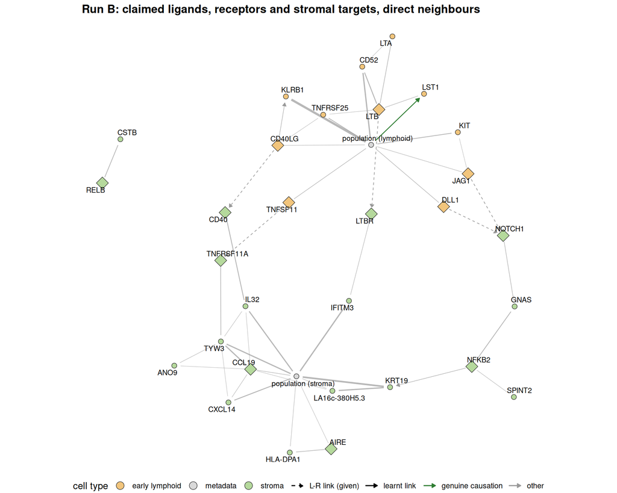

```r
static <- plot_network_static(claim_net, title = "Run B: claimed ligands, receptors and stromal targets, direct neighbours")
ggsave(file.path(fig_dir, "09_runB_claims_neighbourhood.png"), static, width = 11, height = 9, dpi = 200)
static
```

**Reading – sender side (lymphoid cells).**

- **TNFSF11 (RANKL) is linked only to the lymphoid population**, besides its receptor. Its expression is explained by which population a cell belongs to – mainly ILC3 (26% of cells detect it, notebook 03). This agrees with the paper’s “RANKL-RANK signaling is confined between ILC3 and mTEC(II)s”, on the ligand side.
- **CD40LG** is linked to the lymphoid population and to KLRB1 (CD161, an ILC/NK marker; oriented CD40LG → KLRB1) and TNFRSF25. It is expressed mainly by ILC3 (13%).
- **LTB is not linked to population**: it is linked to LTA, its partner in the membrane lymphotoxin (LTα1β2) that binds LTβR, and to LST1, CD52 and TNFRSF25, genes of immune cells. This fits the paper’s “comes from diverse immune cells”: LTB is expressed by 61–94% of every lymphoid population (notebook 03), so population does not explain it.
- JAG1 and DLL1, as ligands of lymphoid cells in this direction, are linked to the lymphoid population (JAG1 also to KIT).

**Receiver side (stromal cells).** Each receptor has a single neighbour besides its ligands: LTBR – IFITM3, TNFRSF11A (RANK) – TYW3, CD40 – IL32, NOTCH1 – GNAS (a depth-following gene, ρ = 0.79).

## 4. Receiver side: are the receptors connected to their targets?

Shortest paths through stromal genes only (not through metadata variables), from each receptor to each target.

```r
stromal <- net |> filter(!is_lr, side[x] == "stroma", side[y] == "stroma")
graph <- igraph::graph_from_data_frame(select(stromal, x, y), directed = FALSE)
expand_grid(receptor = receptor_vars, target = target_vars) |>
  pmap(\(receptor, target) {
    if (!all(c(receptor, target) %in% igraph::V(graph)$name))
      return(tibble(receptor = label(receptor), target = label(target), steps = NA, path = "not connected"))
    p <- igraph::shortest_paths(graph, receptor, target)$vpath[[1]]$name
    tibble(receptor = label(receptor), target = label(target), steps = if (length(p)) length(p) - 1 else NA,
           path = if (length(p)) paste(label(p), collapse = " – ") else "not connected")
  }) |>
  bind_rows() |>
  knitr::kable()
```

| receptor | target | steps | path |
| --- | --- | --- | --- |
| LTBR | NFKB2 | 7 | LTBR – IFITM3 – IGF2 – CAV1 – ECSCR – B2M – GNAS – NFKB2 |
| LTBR | RELB | 8 | LTBR – IFITM3 – IGF2 – CAV1 – ECSCR – H3F3B – H3F3A – CSTB – RELB |
| LTBR | CCL19 | 9 | LTBR – IFITM3 – IGF2 – CAV1 – ECSCR – H3F3B – DSP – KRT19 – LA16c-380H5.3 – CCL19 |
| LTBR | AIRE | 9 | LTBR – IFITM3 – IGF2 – CAV1 – ECSCR – B2M – HLA-B – CD74 – HLA-DPA1 – AIRE |
| TNFRSF11A | NFKB2 | 4 | TNFRSF11A – TYW3 – CALML3 – KRT19 – NFKB2 |
| TNFRSF11A | RELB | 5 | TNFRSF11A – TYW3 – CALML3 – HLA-DQB1 – CSTB – RELB |
| TNFRSF11A | CCL19 | 2 | TNFRSF11A – TYW3 – CCL19 |
| TNFRSF11A | AIRE | 6 | TNFRSF11A – TYW3 – ASCL1 – LINC01551 – HLA-DRA – HLA-DPA1 – AIRE |
| CD40 | NFKB2 | 4 | CD40 – IL32 – KRT5 – KRT19 – NFKB2 |
| CD40 | RELB | 6 | CD40 – IL32 – TYW3 – CALML3 – HLA-DQB1 – CSTB – RELB |
| CD40 | CCL19 | 2 | CD40 – IL32 – CCL19 |
| CD40 | AIRE | 5 | CD40 – IL32 – KRT5 – HLA-DRA – HLA-DPA1 – AIRE |
| NOTCH1 | NFKB2 | 2 | NOTCH1 – GNAS – NFKB2 |
| NOTCH1 | RELB | 4 | NOTCH1 – GNAS – H3F3A – CSTB – RELB |
| NOTCH1 | CCL19 | 5 | NOTCH1 – GNAS – NFKB2 – KRT19 – LA16c-380H5.3 – CCL19 |
| NOTCH1 | AIRE | 6 | NOTCH1 – GNAS – B2M – HLA-B – CD74 – HLA-DPA1 – AIRE |

```r
map(c(receptor_vars, target_vars), \(v) orientation_from(net, v)) |> bind_rows()
```

```
        node            neighbor  neighbor_side                arrow is_causal
1       LTBR              IFITM3         stroma                 none         N
2       LTBR                 LTB early lymphoid          LTB -> LTBR         N
3  TNFRSF11A                TYW3         stroma                 none         N
4  TNFRSF11A             TNFSF11 early lymphoid TNFSF11 -> TNFRSF11A         N
5       CD40                IL32         stroma                 none         N
6       CD40              CD40LG early lymphoid       CD40LG -> CD40         N
7     NOTCH1                GNAS         stroma                 none         N
8     NOTCH1                JAG1 early lymphoid       JAG1 -> NOTCH1         N
9     NOTCH1                DLL1 early lymphoid       DLL1 -> NOTCH1         N
10     NFKB2                GNAS         stroma                 none         N
11     NFKB2              SPINT2         stroma                 none         N
12     NFKB2               KRT19         stroma       NFKB2 -> KRT19         N
13      RELB                CSTB         stroma                 none         N
14     CCL19                TYW3         stroma                 none         N
```

[output cut: 29 more lines]

## 5. Both directions together

For each claimed pair: was it in each run, what is the ligand linked to on its own side (besides its receptor), what is the receptor linked to, and how close is the receptor to a downstream target (stromal targets in run B, Notch targets in run A)?

```r
neighbours <- function(n, v) setdiff(sort(c(n$y[n$x == v], n$x[n$y == v])), character())
describe <- function(n, s, lig_side, rec_side, lig, rec, lab) {
  lv <- var_of(lig, lig_side, s); rv <- var_of(rec, rec_side, s)
  if (is.na(lv) || is.na(rv) || !(link_name(lv, rv) %in% n$link[n$is_lr]))
    return(tibble(ligand_links = "not in this run", receptor_links = ""))
  tibble(ligand_links   = paste(setdiff(lab(neighbours(n, lv)), lab(rv)), collapse = ", "),
         receptor_links = paste(setdiff(lab(neighbours(n, rv)), lab(neighbours(n, rv)[side_of_any(n, rv, s)])),
                                collapse = ", "))
}
# Neighbours of a receptor that are its imposed ligands are not listed
side_of_any <- function(n, rv, s) neighbours(n, rv) %in% c(n$x[n$is_lr & n$y == rv], n$y[n$is_lr & n$x == rv])
label_a <- function(v) {
  base <- str_remove(v, "_(senders|receivers)$")
  case_when(str_ends(v, "_senders") & side_a[v] == "metadata" ~ paste(base, "(stroma)"),
            str_ends(v, "_receivers") & side_a[v] == "metadata" ~ paste(base, "(lymphoid)"),
            .default = base)
}
all_pairs <- tribble(~ligand, ~receptor,
                     "DLL4", "NOTCH1", "JAG2", "NOTCH1", "JAG1", "NOTCH1", "DLL1", "NOTCH1",
                     "LTB", "LTBR", "TNFSF11", "TNFRSF11A", "CD40LG", "CD40")
bind_rows(
  all_pairs |> mutate(run = "A (stroma -> lymphoid)",
                      d = map2(ligand, receptor, \(l, r) describe(net_a, side_a, "stroma", "early lymphoid", l, r, label_a))),
  all_pairs |> mutate(run = "B (lymphoid -> stroma)",
                      d = map2(ligand, receptor, \(l, r) describe(net, side, "early lymphoid", "stroma", l, r, label)))) |>
  unnest(d) |>
  filter(ligand_links != "not in this run") |>
  arrange(ligand, run) |>
  knitr::kable()
```

| ligand | receptor | run | ligand_links | receptor_links |
| --- | --- | --- | --- | --- |
| CD40LG | CD40 | B (lymphoid -> stroma) | KLRB1, population (lymphoid), TNFRSF25 | IL32 |
| DLL1 | NOTCH1 | A (stroma -> lymphoid) | PLXND1 | CD99, n_counts (lymphoid) |
| DLL1 | NOTCH1 | B (lymphoid -> stroma) | population (lymphoid) | GNAS |
| DLL4 | NOTCH1 | A (stroma -> lymphoid) | population (stroma) | CD99, n_counts (lymphoid) |
| JAG1 | NOTCH1 | A (stroma -> lymphoid) | HES4, IGFBP2 | CD99, n_counts (lymphoid) |
| JAG1 | NOTCH1 | B (lymphoid -> stroma) | KIT, population (lymphoid) | GNAS |
| JAG2 | NOTCH1 | A (stroma -> lymphoid) | GNAS, population (stroma) | CD99, n_counts (lymphoid) |
| LTB | LTBR | B (lymphoid -> stroma) | CD52, LST1, LTA, TNFRSF25 | IFITM3 |
| TNFSF11 | TNFRSF11A | B (lymphoid -> stroma) | population (lymphoid) | TYW3 |

**Reading.** The two directions tell the same story:

- **Sender side – who expresses the ligand: consistent with the paper in both runs.** The specific ligands depend on population (DLL4, JAG2 in the stroma; RANKL, CD40LG in the lymphoid cells); the broadly expressed LTB does not, and is linked to its partner LTA.
- **Receiver side – the receptors have few links** (one or two genes, often depth-related), and none is directly linked to its downstream targets; the targets follow the receiving population instead.

## Summary

| Claim (paper) | Run | Ligand side | Receptor side |
| --- | --- | --- | --- |
| JAG2 / DLL4 from cTEC and Endo → NOTCH1 on ETP | A | DLL4, JAG2 depend on stromal population ✓ | NOTCH1 linked to depth, CD99; targets not directly linked |
| LTB from diverse immune cells → LTBR on most stromal cells | B | LTB broadly expressed, not population-specific, linked to LTA ✓ | LTBR linked to IFITM3 only; targets 7–9 steps away |
| RANKL from ILC3 → RANK on mTEC(II) | B | RANKL depends on lymphoid population (ILC3) ✓ | RANK linked to TYW3 only; CCL19 2 steps, AIRE 6 |
| CD40LG → CD40 (dot plot) | B | CD40LG depends on lymphoid population (ILC3), linked to KLRB1 | CD40 linked to IL32 only; CCL19 2 steps |

**Conclusion for the early thymic niche (7–11 PCW).**

1. **The expression side of every claim is reproduced** with CausalCCC in both directions: the networks explain the expression of the specific ligands by the identity of the sending population, and the broadly expressed LTB by its lymphotoxin partner – what the authors’ dot plots and CellPhoneDB means showed.
2. **The signalling side is not resolved.** No receptor is directly linked to its downstream targets; the targets follow the identity of the receiving cells. For these receptors (Notch, LTβR, RANK, CD40), activation does not change the receptor’s mRNA, so this is a limit of what a gene-expression network can show, not evidence against the claims.
3. **Confounders matter.** Sequencing depth still structures part of both networks (24% and 32% of gene–gene links join depth-following genes, about twice chance), and in the stroma, population and donor are confounded (cTEC and mTEC(II) come almost only from two donors).

**Limits.** The L–R links are imposed by CausalCCC, not inferred; the claims are tested only within the 7–11 PCW window and the merged sender / receiver groups of notebook 04.